# Poisson Regression

Spatial Statistics

Relative Risk for Poisson Regression

Yeongeun Jeon  
12-16-2020

# **Poisson Regression**

- Target($y$)이 이산형(Discrete)로 셀 수 있는 Count Data일 때 사용
- 관심있는 모수(Parameter) : $y$의 평균 $\lambda_{i}=E(y_{i})$
  $$\begin{align*}
  y_{i} &\thicksim Poisson(\lambda_{i}), \;\; \lambda_{i} = E(y_{i})\\
  \eta_{i} &= \log{\lambda_{i}} = \beta_{0}+ \sum_{j} \beta_{j}x_{ji}\\
  \beta_{j} &\thicksim Normal
  \end{align*}$$
- $\exp(\beta_{0})$
  - 수치형 : 예측변수들이 0일 때 평균 사건 수
  - 범주형 : Reference Category일 때 평균 사건 수
- $\exp(\beta_{j})$
  - 예측변수들이 1단위 변화할 때 $y$의 평균 변화

## **Relative Risk**

실제로 $y$의 평균 보다 `"Rate"` or `"Relative Risk"`에 더 관심있으며, Poisson Regression의 목적은 `Relative Risk을 추정하는 것`이다. 왜냐하면 단순히 “수”로는 어느 게 크고 작은지 또는 높고 낮은지 정확하게 판단할 수 있는 기준이 없기 때문이다.

$$\begin{align*}
y_{i} &\thicksim Poisson(\lambda_{i}), \;\; \lambda_{i} = E_{i}\rho_{i}\\
\eta_{i} &= \log{\rho_{i}}= \log{\frac{\lambda_{i}}{E_{i}}} = \beta_{0}+ \sum_{j} \beta_{j}x_{ji}\\
\beta_{j} &\thicksim Normal
\end{align*}$$

- $E_{i}$ : Offset
- $\rho_{i}$ : `"Rate"` or `"Relative Risk"`
- $\exp(\beta_{0})$
  - 수치형 : 예측변수들이 0일 때 평균 사건 수
  - 범주형 : Reference Category일 때 평균 사건 수
- $\exp(\beta_{j})$ :
  - 수치형 : $x_{ji}$이 1 증가할 때 `"Rate"` or `"Relative Risk"`의 변화
  - 범주형 : Reference Category와 비교할 때 `"Rate"` or `"Relative Risk"`의 변화

### **Real Data**

#### **Loading Data**

```
pacman::p_load("maptools",     # For readShapePoly
               "spdep",        # For poly2nb
               "dplyr",
               "ggplot2",
               "RColorBrewer", # For brewer.pal
               "INLA")



dat.2019   <- read.csv("2019_crime.csv",header=T)

# Convert rows in the order of ESPI_PK
dat.2019 <- dat.2019[order(dat.2019$ESRI_PK),]

head(dat.2019)
```

```
   ESRI_PK year district rape pop_total pop_femal sec_fac
10       0 2019   도봉구   90    335631    171670      10
12       1 2019   은평구  194    484546    251186      22
6        2 2019 동대문구  168    363023    184533      21
20       3 2019   동작구  251    408912    211206      18
18       4 2019   금천구  153    251820    122866      13
17       5 2019   구로구  226    439371    219769      17
   safe_return_use
10           12602
12           10145
6            20776
20           18766
18           17946
17           15233
```

#### **Loading .shp**

```
seoul.map   <- maptools::readShapePoly("./TL_SCCO_SIG_W_SHP/TL_SCCO_SIG_W.shp")   # Call .shp file
seoul.nb    <- poly2nb(seoul.map)      # Builds a neighbours list based on regions with contiguous boundaries
seoul.listw <- nb2listw(seoul.nb)      # Supplements a neighbours list with spatial weights for the chosen coding scheme
seoul.mat   <- nb2mat(seoul.nb)        # Generates a weights matrix for a neighbours list with spatial weights for the chosen coding scheme
                                       # Object of class "nb"
```

#### **Mapping**

##### **Frequency**

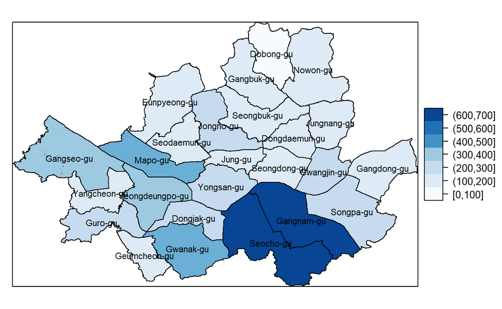

- 빈도로는 단순히 강남과 서초구가 가장 높게 나오지만 우리는 (600,700] 구간이 얼마나 빈도가 많은건지 정확하게 알 수 없다.

##### **Relative Risk**

```
or   <- dat.2019$rape
E    <- dat.2019$pop_total*( sum(dat.2019$rape) / sum(dat.2019$pop_total))
or.p <- dat.2019$rape/E
```

$$\begin{align*}
\hat{\rho} = \frac{y_{i}}{E_{i}} = \frac{y_{i}/n_{i}}{\sum y_{i}/ \sum n_{i}}
\end{align*}$$

- 가장 많이 사용되는 Offset은 전체지역의 전반적인 비율이다.

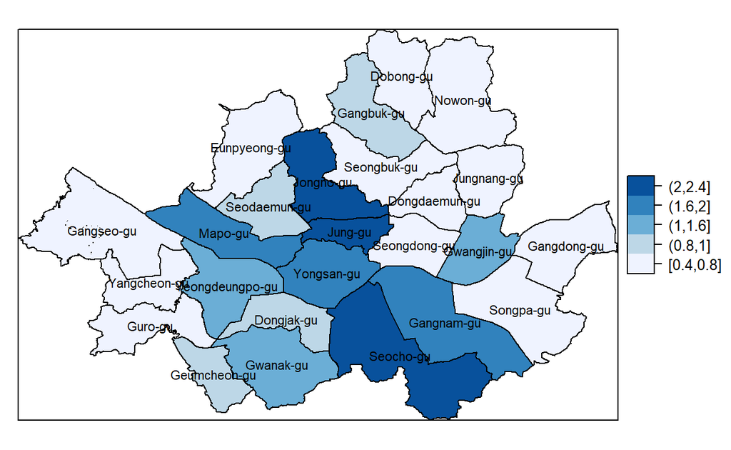

- 1보다 크면 $\frac{y_{i}}{n_{i}}$ 가 $\frac{\sum y_{i}}{\sum n_{i}}$보다 큰 것이므로 $i$번째 지역의 비율은 전체 지역의 비율보다 크다.
  - 즉, $\frac{\sum y_{i}}{\sum n_{i}}$라는 비교 대상이 있으므로 어느정도 큰 것인지 알 수 있다.